# HOW CAN BELLABEAT PLAY IT SMART

Sheikh Rabia Assad

2023-03-06

# 1.SUMMARY

Bellabeat is a high-tech company that manufactures health-focused smart products.They offer different smart devices that collect data on activity, sleep, stress and reproductive health to empower women with knowledge about their own health and habits.

The main focus of this case study is to analyze smart device usage data in order to gain insight into how consumers use non-Bellabeat smart devices and determine how it could help unlock new growth opportunities for Bellabeat. We will focus on one of Bellabeat’s products: **Bellabeat App**

The Bellabeat app provides users with health data related to their activity, sleep, stress,menstrual cycle, and mindfulness habits. This data can help users understand their current habits and make healthy decisions in a better way.

# 2.ASK PHASE

### 2.1 Business Task

Identifying trends in non-Bellabeat smart devices to gain insights and apply them into Bellabeat’s marketing strategy.

### 2.2 Stakeholders

Urška Sršen: Bellabeat’s cofounder and Chief Creative Officer.

Sando Mur: Bellabeat’s cofounder and key member of the Bellabeat executive team.

Bellabeat marketing analytics team.

# 3. PREPARE PHASE

### 3.1 Dataset used

The dataset used in this case study is FitBit Fitness Tracker data. This is a kaggle dataset made available through Mobius.

### 3.3 Data Organization

The data contains 18 CSV documents. Each document represents different quantitative data tracked by Fitbit. The data is considered long since each row is one time point per subject so each subject will have data in multiple rows. Every user has a unique ID and different rows since data is tracked by day and time.

# 4. PROCESS PHASE

We will focus our analysis in R due to accessibility, amount of data and ability to create data visualization so that we can share our results with the stakeholders.

### 4.1 Installing and Loading Packages.

we will use the following packages for our analysis.

1.tidyverse

2.dplyr

3.readr

4.ggplot2

```r
library("tidyverse")
```

```r
library("dplyr")
library("ggplot2")
library("readr")
```

### 4.2 Importing Dataset

The dataset contains 18 csv files but we will import the following files that will help us in our business task:

1. Daily Calories
2. Daily Activity
3. Daily Intensities
4. Weight
5. Daily Sleep

6.Hourly steps

```r
 daily_activity <- read_csv("fit bit/Fitabase Data 4.12.16-5.12.16/dailyActivity_merged.csv")
 daily_calories <- read_csv("fit bit/Fitabase Data 4.12.16-5.12.16/dailyCalories_merged.csv")
 daily_intensities <- read_csv("fit bit/Fitabase Data 4.12.16-5.12.16/dailyIntensities_merged.csv")
 weight <- read_csv("fit bit/Fitabase Data 4.12.16-5.12.16/weightLogInfo_merged.csv")
  daily_sleep <- read_csv("fit bit/Fitabase Data 4.12.16-5.12.16/sleepDay_merged.csv")
 hourly_steps<- read_csv("fit bit/Fitabase Data 4.12.16-5.12.16/hourlySteps_merged.csv")
```

### 4.3 Overview of Dataset

To get an idea about the number of columns and structure of dataset:

```r
head(daily_activity)
```

```
## # A tibble: 6 × 15
##           Id ActivityDate TotalSteps TotalDistance TrackerDistance
##        <dbl> <chr>             <dbl>         <dbl>           <dbl>
## 1 1503960366 4/12/2016         13162          8.5             8.5
## 2 1503960366 4/13/2016         10735          6.97            6.97
## 3 1503960366 4/14/2016         10460          6.74            6.74
## 4 1503960366 4/15/2016          9762          6.28            6.28
## 5 1503960366 4/16/2016         12669          8.16            8.16
## 6 1503960366 4/17/2016          9705          6.48            6.48
## # ℹ 10 more variables: LoggedActivitiesDistance <dbl>,
## #   VeryActiveDistance <dbl>, ModeratelyActiveDistance <dbl>,
## #   LightActiveDistance <dbl>, SedentaryActiveDistance <dbl>,
## #   VeryActiveMinutes <dbl>, FairlyActiveMinutes <dbl>,
## #   LightlyActiveMinutes <dbl>, SedentaryMinutes <dbl>, Calories <dbl>
```

```r
str(daily_activity)
```

```
## spc_tbl_ [940 × 15] (S3: spec_tbl_df/tbl_df/tbl/data.frame)
##  $ Id                      : num [1:940] 1.5e+09 1.5e+09 1.5e+09 1.5e+09 1.5e+09 ...
##  $ ActivityDate            : chr [1:940] "4/12/2016" "4/13/2016" "4/14/2016" "4/15/2016" ...
##  $ TotalSteps              : num [1:940] 13162 10735 10460 9762 12669 ...
##  $ TotalDistance           : num [1:940] 8.5 6.97 6.74 6.28 8.16 ...
##  $ TrackerDistance         : num [1:940] 8.5 6.97 6.74 6.28 8.16 ...
##  $ LoggedActivitiesDistance: num [1:940] 0 0 0 0 0 0 0 0 0 0 ...
##  $ VeryActiveDistance      : num [1:940] 1.88 1.57 2.44 2.14 2.71 ...
##  $ ModeratelyActiveDistance: num [1:940] 0.55 0.69 0.4 1.26 0.41 ...
##  $ LightActiveDistance     : num [1:940] 6.06 4.71 3.91 2.83 5.04 ...
##  $ SedentaryActiveDistance : num [1:940] 0 0 0 0 0 0 0 0 0 0 ...
##  $ VeryActiveMinutes       : num [1:940] 25 21 30 29 36 38 42 50 28 19 ...
##  $ FairlyActiveMinutes     : num [1:940] 13 19 11 34 10 20 16 31 12 8 ...
##  $ LightlyActiveMinutes    : num [1:940] 328 217 181 209 221 164 233 264 205 211 ...
##  $ SedentaryMinutes        : num [1:940] 728 776 1218 726 773 ...
##  $ Calories                : num [1:940] 1985 1797 1776 1745 1863 ...
##  - attr(*, "spec")=
##   .. cols(
##   ..   Id = col_double(),
##   ..   ActivityDate = col_character(),
##   ..   TotalSteps = col_double(),
##   ..   TotalDistance = col_double(),
##   ..   TrackerDistance = col_double(),
##   ..   LoggedActivitiesDistance = col_double(),
##   ..   VeryActiveDistance = col_double(),
##   ..   ModeratelyActiveDistance = col_double(),
##   ..   LightActiveDistance = col_double(),
##   ..   SedentaryActiveDistance = col_double(),
##   ..   VeryActiveMinutes = col_double(),
##   ..   FairlyActiveMinutes = col_double(),
##   ..   LightlyActiveMinutes = col_double(),
##   ..   SedentaryMinutes = col_double(),
##   ..   Calories = col_double()
##   .. )
##  - attr(*, "problems")=<externalptr>
```

```r
head( daily_calories)
```

```
## # A tibble: 6 × 3
##           Id ActivityDay Calories
##        <dbl> <chr>          <dbl>
## 1 1503960366 4/12/2016       1985
## 2 1503960366 4/13/2016       1797
## 3 1503960366 4/14/2016       1776
## 4 1503960366 4/15/2016       1745
## 5 1503960366 4/16/2016       1863
## 6 1503960366 4/17/2016       1728
```

```r
str(daily_calories)
```

```
## spc_tbl_ [940 × 3] (S3: spec_tbl_df/tbl_df/tbl/data.frame)
##  $ Id         : num [1:940] 1.5e+09 1.5e+09 1.5e+09 1.5e+09 1.5e+09 ...
##  $ ActivityDay: chr [1:940] "4/12/2016" "4/13/2016" "4/14/2016" "4/15/2016" ...
##  $ Calories   : num [1:940] 1985 1797 1776 1745 1863 ...
##  - attr(*, "spec")=
##   .. cols(
##   ..   Id = col_double(),
##   ..   ActivityDay = col_character(),
##   ..   Calories = col_double()
##   .. )
##  - attr(*, "problems")=<externalptr>
```

```r
head( daily_intensities)
```

```
## # A tibble: 6 × 10
##         Id ActivityDay SedentaryMinutes LightlyActiveMinutes FairlyActiveMinutes
##      <dbl> <chr>                  <dbl>                <dbl>               <dbl>
## 1   1.50e9 4/12/2016                728                  328                  13
## 2   1.50e9 4/13/2016                776                  217                  19
## 3   1.50e9 4/14/2016               1218                  181                  11
## 4   1.50e9 4/15/2016                726                  209                  34
## 5   1.50e9 4/16/2016                773                  221                  10
## 6   1.50e9 4/17/2016                539                  164                  20
## # ℹ 5 more variables: VeryActiveMinutes <dbl>, SedentaryActiveDistance <dbl>,
## #   LightActiveDistance <dbl>, ModeratelyActiveDistance <dbl>,
## #   VeryActiveDistance <dbl>
```

```r
str( daily_intensities)
```

```
## spc_tbl_ [940 × 10] (S3: spec_tbl_df/tbl_df/tbl/data.frame)
##  $ Id                      : num [1:940] 1.5e+09 1.5e+09 1.5e+09 1.5e+09 1.5e+09 ...
##  $ ActivityDay             : chr [1:940] "4/12/2016" "4/13/2016" "4/14/2016" "4/15/2016" ...
##  $ SedentaryMinutes        : num [1:940] 728 776 1218 726 773 ...
##  $ LightlyActiveMinutes    : num [1:940] 328 217 181 209 221 164 233 264 205 211 ...
##  $ FairlyActiveMinutes     : num [1:940] 13 19 11 34 10 20 16 31 12 8 ...
##  $ VeryActiveMinutes       : num [1:940] 25 21 30 29 36 38 42 50 28 19 ...
##  $ SedentaryActiveDistance : num [1:940] 0 0 0 0 0 0 0 0 0 0 ...
##  $ LightActiveDistance     : num [1:940] 6.06 4.71 3.91 2.83 5.04 ...
##  $ ModeratelyActiveDistance: num [1:940] 0.55 0.69 0.4 1.26 0.41 ...
##  $ VeryActiveDistance      : num [1:940] 1.88 1.57 2.44 2.14 2.71 ...
##  - attr(*, "spec")=
##   .. cols(
##   ..   Id = col_double(),
##   ..   ActivityDay = col_character(),
##   ..   SedentaryMinutes = col_double(),
##   ..   LightlyActiveMinutes = col_double(),
##   ..   FairlyActiveMinutes = col_double(),
##   ..   VeryActiveMinutes = col_double(),
##   ..   SedentaryActiveDistance = col_double(),
##   ..   LightActiveDistance = col_double(),
##   ..   ModeratelyActiveDistance = col_double(),
##   ..   VeryActiveDistance = col_double()
##   .. )
##  - attr(*, "problems")=<externalptr>
```

```r
head( weight )
```

```
## # A tibble: 6 × 8
##           Id Date       WeightKg WeightPounds   Fat   BMI IsManualReport   LogId
##        <dbl> <chr>         <dbl>        <dbl> <dbl> <dbl> <lgl>            <dbl>
## 1 1503960366 5/2/2016 …     52.6         116.    22  22.6 TRUE           1.46e12
## 2 1503960366 5/3/2016 …     52.6         116.    NA  22.6 TRUE           1.46e12
## 3 1927972279 4/13/2016…    134.          294.    NA  47.5 FALSE          1.46e12
## 4 2873212765 4/21/2016…     56.7         125.    NA  21.5 TRUE           1.46e12
## 5 2873212765 5/12/2016…     57.3         126.    NA  21.7 TRUE           1.46e12
## 6 4319703577 4/17/2016…     72.4         160.    25  27.5 TRUE           1.46e12
```

```r
str( weight )
```

```
## spc_tbl_ [67 × 8] (S3: spec_tbl_df/tbl_df/tbl/data.frame)
##  $ Id            : num [1:67] 1.50e+09 1.50e+09 1.93e+09 2.87e+09 2.87e+09 ...
##  $ Date          : chr [1:67] "5/2/2016 11:59:59 PM" "5/3/2016 11:59:59 PM" "4/13/2016 1:08:52 AM" "4/21/2016 11:59:59 PM" ...
##  $ WeightKg      : num [1:67] 52.6 52.6 133.5 56.7 57.3 ...
##  $ WeightPounds  : num [1:67] 116 116 294 125 126 ...
##  $ Fat           : num [1:67] 22 NA NA NA NA 25 NA NA NA NA ...
##  $ BMI           : num [1:67] 22.6 22.6 47.5 21.5 21.7 ...
##  $ IsManualReport: logi [1:67] TRUE TRUE FALSE TRUE TRUE TRUE ...
##  $ LogId         : num [1:67] 1.46e+12 1.46e+12 1.46e+12 1.46e+12 1.46e+12 ...
##  - attr(*, "spec")=
##   .. cols(
##   ..   Id = col_double(),
##   ..   Date = col_character(),
##   ..   WeightKg = col_double(),
##   ..   WeightPounds = col_double(),
##   ..   Fat = col_double(),
##   ..   BMI = col_double(),
##   ..   IsManualReport = col_logical(),
##   ..   LogId = col_double()
##   .. )
##  - attr(*, "problems")=<externalptr>
```

```r
head( daily_sleep)
```

```
## # A tibble: 6 × 5
##           Id SleepDay        TotalSleepRecords TotalMinutesAsleep TotalTimeInBed
##        <dbl> <chr>                       <dbl>              <dbl>          <dbl>
## 1 1503960366 4/12/2016 12:0…                 1                327            346
## 2 1503960366 4/13/2016 12:0…                 2                384            407
## 3 1503960366 4/15/2016 12:0…                 1                412            442
## 4 1503960366 4/16/2016 12:0…                 2                340            367
## 5 1503960366 4/17/2016 12:0…                 1                700            712
## 6 1503960366 4/19/2016 12:0…                 1                304            320
```

```r
str( daily_sleep)
```

```
## spc_tbl_ [413 × 5] (S3: spec_tbl_df/tbl_df/tbl/data.frame)
##  $ Id                : num [1:413] 1.5e+09 1.5e+09 1.5e+09 1.5e+09 1.5e+09 ...
##  $ SleepDay          : chr [1:413] "4/12/2016 12:00:00 AM" "4/13/2016 12:00:00 AM" "4/15/2016 12:00:00 AM" "4/16/2016 12:00:00 AM" ...
##  $ TotalSleepRecords : num [1:413] 1 2 1 2 1 1 1 1 1 1 ...
##  $ TotalMinutesAsleep: num [1:413] 327 384 412 340 700 304 360 325 361 430 ...
##  $ TotalTimeInBed    : num [1:413] 346 407 442 367 712 320 377 364 384 449 ...
##  - attr(*, "spec")=
##   .. cols(
##   ..   Id = col_double(),
##   ..   SleepDay = col_character(),
##   ..   TotalSleepRecords = col_double(),
##   ..   TotalMinutesAsleep = col_double(),
##   ..   TotalTimeInBed = col_double()
##   .. )
##  - attr(*, "problems")=<externalptr>
```

```r
head( hourly_steps)
```

```
## # A tibble: 6 × 3
##           Id ActivityHour          StepTotal
##        <dbl> <chr>                     <dbl>
## 1 1503960366 4/12/2016 12:00:00 AM       373
## 2 1503960366 4/12/2016 1:00:00 AM        160
## 3 1503960366 4/12/2016 2:00:00 AM        151
## 4 1503960366 4/12/2016 3:00:00 AM          0
## 5 1503960366 4/12/2016 4:00:00 AM          0
## 6 1503960366 4/12/2016 5:00:00 AM          0
```

```r
str( hourly_steps)
```

```
## spc_tbl_ [22,099 × 3] (S3: spec_tbl_df/tbl_df/tbl/data.frame)
##  $ Id          : num [1:22099] 1.5e+09 1.5e+09 1.5e+09 1.5e+09 1.5e+09 ...
##  $ ActivityHour: chr [1:22099] "4/12/2016 12:00:00 AM" "4/12/2016 1:00:00 AM" "4/12/2016 2:00:00 AM" "4/12/2016 3:00:00 AM" ...
##  $ StepTotal   : num [1:22099] 373 160 151 0 0 ...
##  - attr(*, "spec")=
##   .. cols(
##   ..   Id = col_double(),
##   ..   ActivityHour = col_character(),
##   ..   StepTotal = col_double()
##   .. )
##  - attr(*, "problems")=<externalptr>
```

### 4.4 Cleaning Dataset

#### 4.4.1 Checking for Distinct Enteries

let us find out the number of distinct enteries in each dataset.

```r
daily_calories %>%
  summarise(n_distinct(Id))
```

```
## # A tibble: 1 × 1
##   `n_distinct(Id)`
##              <int>
## 1               33
```

```r
daily_activity %>%
  summarise(n_distinct(Id))
```

```
## # A tibble: 1 × 1
##   `n_distinct(Id)`
##              <int>
## 1               33
```

```r
 weight %>%
   summarise(n_distinct(Id))
```

```
## # A tibble: 1 × 1
##   `n_distinct(Id)`
##              <int>
## 1                8
```

```r
daily_intensities %>%
  summarise(n_distinct(Id))
```

```
## # A tibble: 1 × 1
##   `n_distinct(Id)`
##              <int>
## 1               33
```

```r
daily_sleep %>%
  summarize(n_distinct(Id))
```

```
## # A tibble: 1 × 1
##   `n_distinct(Id)`
##              <int>
## 1               24
```

```r
hourly_steps %>%
  summarize(n_distinct(Id))
```

```
## # A tibble: 1 × 1
##   `n_distinct(Id)`
##              <int>
## 1               33
```

Since weight has only 8 distinct users which implies that its sample size is very small,thus we will not consider it while analyzing the data.

#### 4.4.2 Renaming Columns

Since we have to merge datasets,its important that the column names should have the same format for that we will rename the column names.

```r
 daily_calories=rename_with(daily_calories,tolower)

 daily_activity=rename_with(daily_activity,tolower)

daily_intensities=rename_with(daily_intensities,tolower)

daily_sleep=rename_with(daily_sleep,tolower)

hourly_steps=rename_with(hourly_steps,tolower)
```

#### 4.4.3 Maintaining consistency of time and date columns

In order to merge datasets we have to maintain the date and time in a single format.

```r
daily_activity = daily_activity %>%
  rename(date = activitydate) %>%
  mutate(date = as_date(date, format = "%m/%d/%Y"))

daily_sleep <- daily_sleep %>%
  rename(date = sleepday) %>%
  mutate(date = as_date(date,format ="%m/%d/%Y %I:%M:%S %p" , tz=Sys.timezone()))
hourly_steps=hourly_steps %>%
  rename(datetime =activityhour) %>%
    mutate(datetime= as.POSIXct(datetime,format ="%m/%d/%Y %I:%M:%S %p" , tz=Sys.timezone()))
```

### 4.5 Merging Datasets

Now we will merge daily_activity and daily_sleep by their common columns and get a single dataset to analyse.

```r
daily_activity_sleep=merge(daily_activity,daily_sleep,by=c("date","id"))
head(daily_activity_sleep)
```

```
##         date         id totalsteps totaldistance trackerdistance
## 1 2016-04-12 1503960366      13162          8.50            8.50
## 2 2016-04-12 1927972279        678          0.47            0.47
## 3 2016-04-12 2026352035       4414          2.74            2.74
## 4 2016-04-12 3977333714       8856          5.98            5.98
## 5 2016-04-12 4020332650       8539          6.12            6.12
## 6 2016-04-12 4445114986       3276          2.20            2.20
##   loggedactivitiesdistance veryactivedistance moderatelyactivedistance
## 1                        0               1.88                     0.55
## 2                        0               0.00                     0.00
## 3                        0               0.19                     0.35
## 4                        0               3.06                     0.91
## 5                        0               0.15                     0.24
## 6                        0               0.00                     0.00
##   lightactivedistance sedentaryactivedistance veryactiveminutes
```

[output cut: 20 more lines]

# 5. ANALYSIS AND SHARE PHASE

### 5.1 Comparison of Totalsteps with Calories and Sleep

**To check any correlation between totalsteps and calories** :

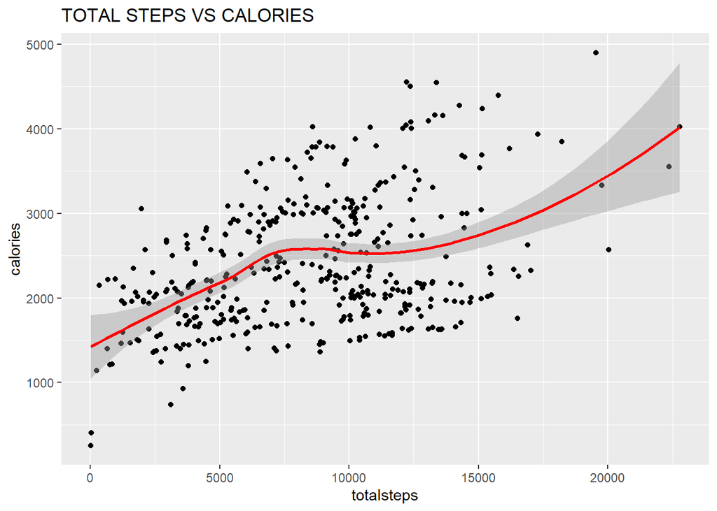

```r
ggplot(data = daily_activity_sleep,aes(x=totalsteps,y=calories))+
  geom_point()+
  geom_smooth(colour="red")+
labs(titles="TOTAL STEPS VS CALORIES")
```

We can see a positive correlation between steps and calories burned. As assumed the more steps walked the more calories may be burnt.

**To check any correlation between totalsteps and minutes slept**

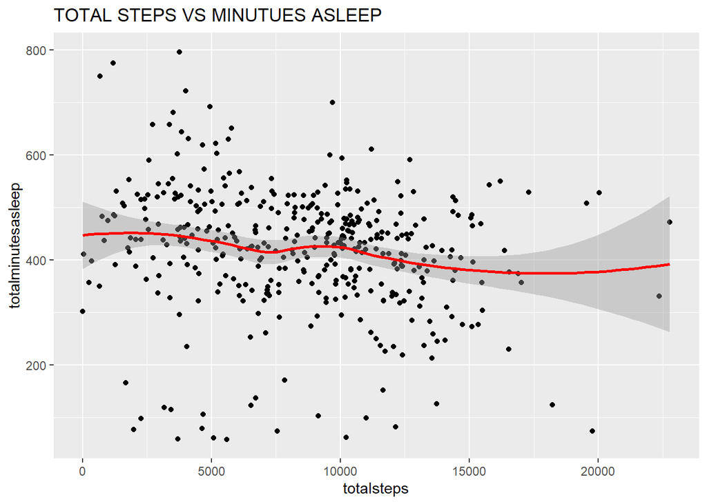

```r
daily_activity_sleep %>%
ggplot(aes(x=totalsteps,y=totalminutesasleep))+
  geom_point()+
  geom_smooth(colour="red")+
  labs(titles="TOTAL STEPS VS MINUTUES ASLEEP")
```

we can see there is no clear relation between minutes slept and steps walked.

### 5.2 User type based on Activity

According to website “10000 Steps Australia”: The following pedometer indices have been developed to provide a guideline on steps and activity levels:

Sedentary is less than 5,000 steps per day,Low active is 5,000 to 7,499 steps per day, Somewhat active is 7,500 to 9,999 steps per day,Active is more than 10,000 steps per day and Highly active is more than 12,500.

let us categories our user type on this basis.

```r
 mean_activity=daily_activity_sleep %>%
  group_by(id) %>%
summarise(meandailysteps=mean(totalsteps),meandailycalories=mean(calories)) %>%
mutate(usertype=
          case_when(meandailysteps<5000~"Sedentary",
            meandailysteps>=5000 & meandailysteps < 7499~"Low active",
                 meandailysteps>=7500&meandailysteps<9999~"Some what active",
                     meandailysteps>=10000&meandailysteps<12500~"Active",
                     meandailysteps>12500~"Highly Active" ))

         head(mean_activity)
```

```
## # A tibble: 6 × 4
##           id meandailysteps meandailycalories usertype
##        <dbl>          <dbl>             <dbl> <chr>
## 1 1503960366         12406.             1872. Active
## 2 1644430081          7968.             2978. Some what active
## 3 1844505072          3477              1676. Sedentary
## 4 1927972279          1490              2316. Sedentary
## 5 2026352035          5619.             1541. Low active
## 6 2320127002          5079              1804  Low active
```

Now let us find percentage of each user type .

```r
usertype_percent= mean_activity %>%
  group_by(usertype) %>%
 summarise(total=n()) %>%
   mutate(totals=sum(total)) %>%
        mutate(percent=total/totals*100)
head(usertype_percent)
```

```
## # A tibble: 5 × 4
##   usertype         total totals percent
##   <chr>            <int>  <int>   <dbl>
## 1 Active               4     24   16.7
## 2 Highly Active        1     24    4.17
## 3 Low active           5     24   20.8
## 4 Sedentary            5     24   20.8
## 5 Some what active     9     24   37.5
```

Now graphically this can be represented as:

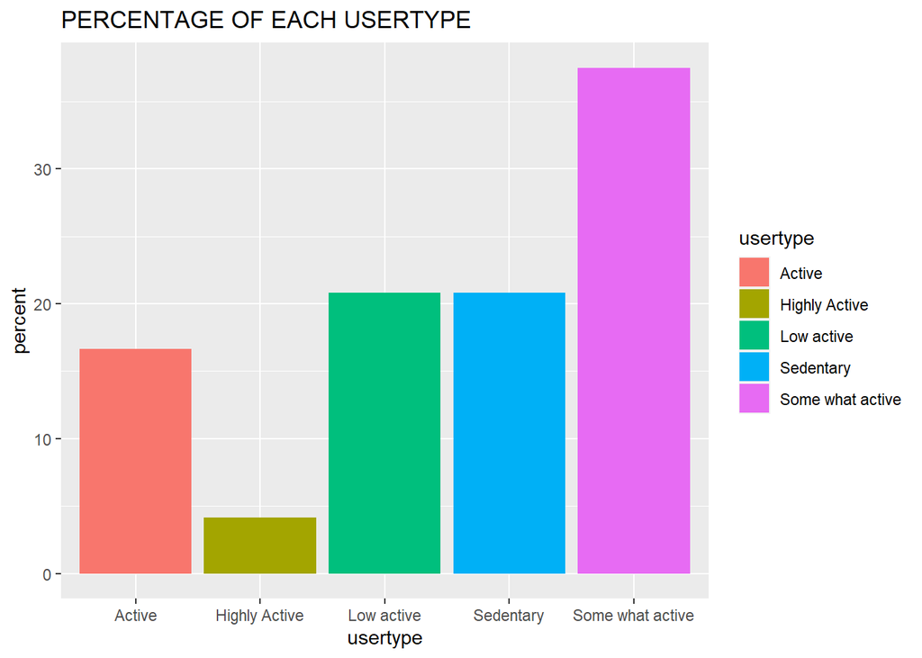

```r
ggplot(data=usertype_percent)+
  geom_col(mapping=aes(x=usertype,y=percent,fill=usertype,))+
  labs(titles="PERCENTAGE OF EACH USERTYPE")
```

### 5.3 Time in Bed vs Total Minutes Asleep.

From the dataset(daily_sleep),we can clearly see total time in bed is different from total minutes asleep . let us figure out the difference between the two.

```r
 mean_sleep=daily_activity_sleep %>%
  group_by(id) %>%
summarise(meantotalminutesasleep=mean(totalminutesasleep),meantimeinbed=mean(totaltimeinbed)) %>%
  mutate(awaketime=meantimeinbed-meantotalminutesasleep)
  head(mean_sleep)
```

```
## # A tibble: 6 × 4
##           id meantotalminutesasleep meantimeinbed awaketime
##        <dbl>                  <dbl>         <dbl>     <dbl>
## 1 1503960366                   360.          383.      22.9
## 2 1644430081                   294           346       52
## 3 1844505072                   652           961      309
## 4 1927972279                   417           438.      20.8
## 5 2026352035                   506.          538.      31.5
## 6 2320127002                    61            69        8
```

Now let us compare the Awake time with the user type to check if there is any relation between the two. Awake time represents the time a person spends in bed before going to sleep.

To draw comparison,let us merge mean_activity and mean_sleep .

```r
mean_activity_sleep=merge(mean_activity,mean_sleep,by="id")
head(mean_activity_sleep)
```

```
##           id meandailysteps meandailycalories         usertype
## 1 1503960366      12405.680          1872.280           Active
## 2 1644430081       7967.750          2977.750 Some what active
## 3 1844505072       3477.000          1676.333        Sedentary
## 4 1927972279       1490.000          2316.200        Sedentary
## 5 2026352035       5618.679          1540.786       Low active
## 6 2320127002       5079.000          1804.000       Low active
##   meantotalminutesasleep meantimeinbed awaketime
## 1               360.2800      383.2000  22.92000
## 2               294.0000      346.0000  52.00000
## 3               652.0000      961.0000 309.00000
## 4               417.0000      437.8000  20.80000
## 5               506.1786      537.6429  31.46429
## 6                61.0000       69.0000   8.00000
```

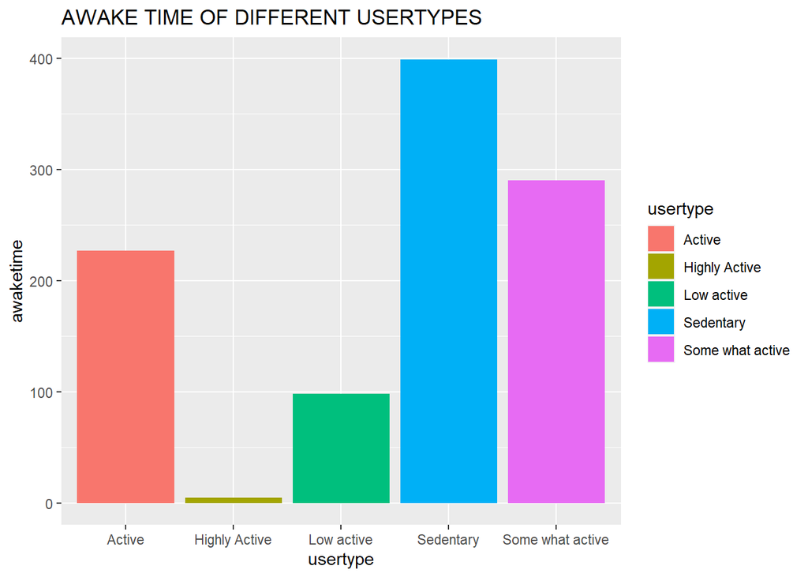

```r
ggplot(data=mean_activity_sleep)+
geom_col(mapping=aes(x=usertype,y=awaketime,fill=usertype))+
  labs(title="AWAKE TIME OF DIFFERENT USERTYPES")
```

### 5.4 Most Active Hours of the Day.

Let us find out the time of the day at which the user is most active.

```r
mean_hourly_steps=hourly_steps %>%
  separate(datetime,into=c("date","time"),sep=" ") %>%
  group_by(time) %>%
  summarise(averagestep=mean(steptotal))
```

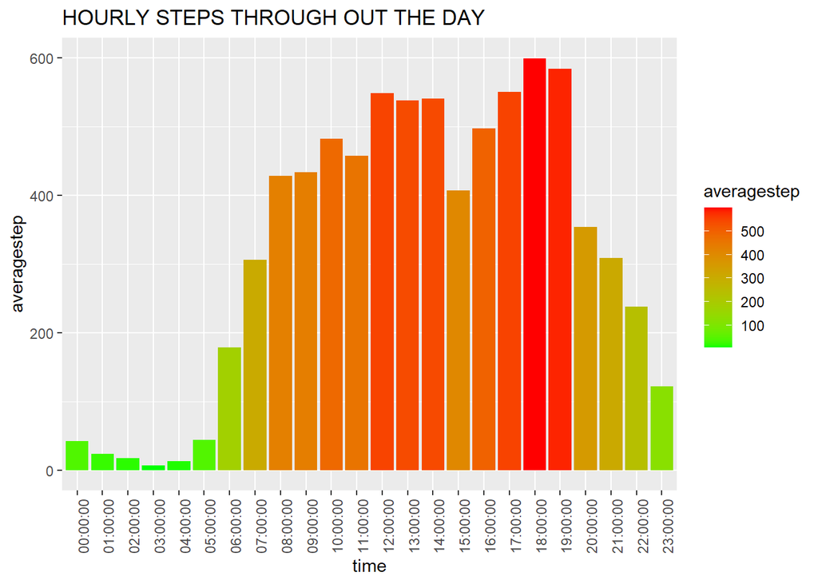

```r
ggplot(data=mean_hourly_steps)+
  geom_col(mapping=aes(x=time,y=averagestep,fill=averagestep))+
  labs(title="HOURLY STEPS THROUGH OUT THE DAY")+
   scale_fill_gradient(low = "green", high = "red")+
   theme(axis.text.x = element_text(angle = 90))
```

The graph clearly indicates the users are most active during 5 to 7 pm (evening time).

# 6 ACT PHASE

### MY Conclusion on the analysis:

- As there is a positive correlation between total steps taken and calories burnt ,we can add an indicator in the app showing the calories burnt for daily steps taken thus encouraging users to walk .
- We can create an activity based Reward System.Users can collect reward points for each activity and after achieving a specific milestone ,the company can reward the user with gift hampers thus encouraging users to do more activity.
- We can send notification on the app reminding users to sleep on time .
- The app should be designed in a way that it shows the benefit of activity on sleeping pattern and stress level.
- As users are more active during evening,we can send notification in evening about the benefits of walk and the effect it has on overall health of the user encouraging them to take a walk.
- We can add some fitness related podcasts and exercise,yoga videos to the app. .